# ESM 244 Assignment 3 Task 1

Author

Jesse Landesman

```r
library(tidymodels)
library(tidyverse)
library(here)
library(ggpubr)
library(knitr)
library(broom)
library(kableExtra)
```

# Overview

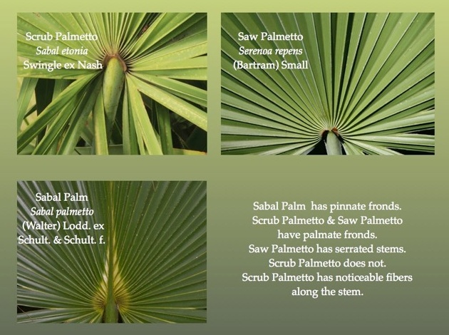

Comparing different species of Palmetto Palm plants. Image citation: Outside My Window. https://www.birdsoutsidemywindow.org/2016/02/27/reading-the-palms/

```r
knitr::include_graphics('data/palmetto.jpeg')
```

## Summary of the dataset:

This data consists of information on two of the dominant species of palmetto in south-central Florida from 1981 to 2017. The data includes many variables on these plants, including plant ID number, sample year, experimental treatment applied, and site name. However, for this analysis, we are interested in the physical plant features, like plant height, canopy width, canopy length, and number of green leaves, and if these variables can predict species type.

**Citation:** *Abrahamson, W.G. 2019. Survival, growth and biomass estimates of two dominant palmetto species of south-central Florida from 1981 - 2017, ongoing at 5-year intervals ver 1. Environmental Data Initiative. https://doi.org/10.6073/pasta/f2f96ec76fbbd4b9db431c79a770c4d5 (Accessed 2024-02-28).*

## Purpose of analysis:

The purpose of this analysis is to use binary logistic regression to see if the parameters plant height, canopy length, canopy width, and number of green leaves can accurately predict whether a palmetto plant is species Serenoa reopens or Sabal etonia. We will compare two different models to see which works better. The first model will include all four parameters I mentioned, and the second model will have the same parameters but without canopy length.After selecting a the better of these two models, we will train the model on the entire dataset and see how accurate the model is in predicting the correct species using the given predictor variables.

## Pseudocode:

- read in the palmetto csv
- clean the data and select only the variables were are interested in including in our model
- do some exploratory plots to see if the variables differ between the two species
- set up the two models and split the data into testing and training data
- cross validate both models with the training data to see which model has a lower AIC and a larger area under the ROC curve
- after choosing a model, use this model to train the entire palmetto dataset
- set up the model to see if it can predict the type of species given the four input variables, using the predict() function

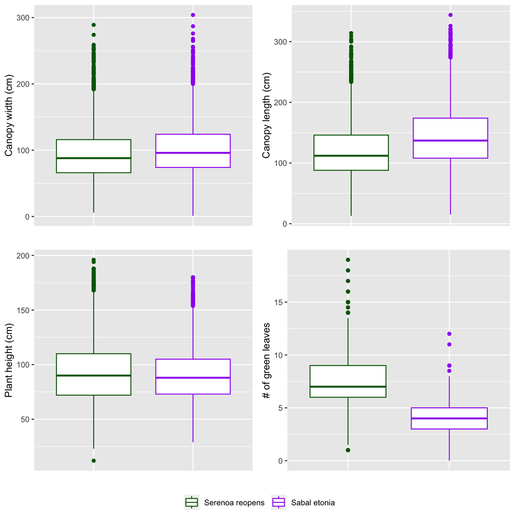

Figure 1: Four separate box plots comparing the four predictor variables (canopy length, canopy width, plant height, and numnber of green leaves) between the two species of palmetto.

```r
# read in the data
palmetto <- read_csv(here('data', 'palmetto.csv'))

# change the species to a factor
# what species is represented by 1? which species is represented by 2?
# 1 is serenoa repens
# 2 is sabal etonia
species_df <- palmetto %>%
  mutate(species = factor(species)) %>%
  select(species, height, length, width, green_lvs)

### exploratory plots: try height, length, etc.
# ggplot(species_df, aes(x = height, fill = species)) +
#   geom_bar()

# ggplot(species_df, aes(x = length, fill = species)) +
#   geom_histogram()

width_plot <- ggplot(species_df, aes(x = species, y = width, color = species)) +
  geom_boxplot()+
  theme(
    axis.text.x = element_blank(),
    axis.ticks.x = element_blank(),
    legend.title = element_blank()
  )+
  labs(x = ' ', y = 'Canopy width (cm)')+
  scale_color_manual(values = c('darkgreen', 'purple'),
                     labels= c('Serenoa reopens', 'Sabal etonia'))

height_plot <- ggplot(species_df, aes(x = species, y = height, color = species)) +
  geom_boxplot()+
  theme(
    axis.text.x = element_blank(),
    axis.ticks.x = element_blank(),
    legend.title = element_blank()
  )+
  labs(x = ' ', y = 'Plant height (cm)')+
  scale_color_manual(values = c('darkgreen', 'purple'),
                     labels= c('Serenoa reopens', 'Sabal etonia'))

length_plot <- ggplot(species_df, aes(x = species, y = length, color = species)) +
  geom_boxplot()+
  theme(
    axis.text.x = element_blank(),
    axis.ticks.x = element_blank(),
    legend.title = element_blank()
  )+
  labs(x = ' ', y = 'Canopy length (cm)')+
   scale_color_manual(values = c('darkgreen', 'purple'),
                     labels= c('Serenoa reopens', 'Sabal etonia'))

green_lvs_plot <- ggplot(species_df, aes(x = species, y = green_lvs, color = species)) +
  geom_boxplot()+
  theme(
    axis.text.x = element_blank(),
    axis.ticks.x = element_blank(),
    legend.title = element_blank()
  )+
  labs(x = ' ', y = '# of green leaves')+
   scale_color_manual(values = c('darkgreen', 'purple'),
                     labels= c('Serenoa reopens', 'Sabal etonia'))

ggarrange(width_plot, length_plot, height_plot, green_lvs_plot, ncol = 2,
          nrow = 2, common.legend = TRUE, legend = "bottom")
```

Based on these box plots showing the differences in canopy width, canopy length, plant height, and count of green leaves between Serenoa reopens and Sabal etonia, the predictor variable that is the most different between the two species is the number of green leaves. This variable will likely help to classify species correctly. A second variable that has a clear difference between the two species is canopy length. This means that models that contain both number of green leaves and canopy length will likely perform better than models without these parameters.